# Relatório Emendas PIX

Paulo

2022-09-29

## Introdução

Este relatório trata das chamadas “emendas PIX”, criadas pela Emenda Constitucional nº 105/2019. Esse tipo de emenda ao orçamento permite que parlamentares enviem recursos federais para estados, DF e municípios sem finalidade definida.

Na lei orçamentária anual (LOA) da União, referidas emendas são autorizadas por intermédio da ação “OEC2 - Transferências Especiais”.

É realizado teste de hipótese para avaliar se tais emendas têm comportamento distinto em relação às emendas individuais tradicionais, particularmente no que se refere ao valor das dotações autorizadas na LOA. Como primeiro passo, apresenta-se a seguir um histograma das dotações autorizadas para as diversas emendas em favor da ação 0EC2 na LOA 2022 da União.

## Histograma real

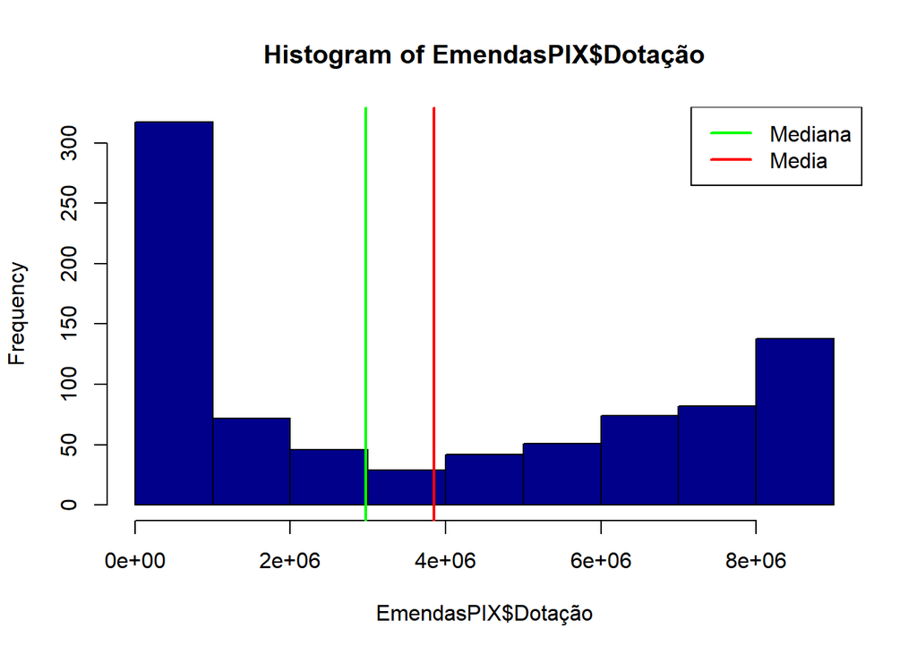

## Estimativa intervalar

Inicialmente, procede-se ao cálculo da estimativa intervalar da variável analisada (dotação emendas PIX) assumindo-se, por simplificação, que sua distribuição tem configuração normal.

Dado que média = R$ 3,8 milhões e desvio padrão = R$ 3,3 milhões, então:

Desvio padrão normalizado = R$ 111,7 mil.

Cálculo dos limites inferior e superior com grau de confiança de 99% (fator 2,58 desvio-padrão):

Lim. Inferior = R$ 3,6 milhões.

Lim. Superior = R$ 4,1 milhões.

```r
média <-round(mean(EmendasPIX$Dotação),2)
desvpad <-round(sd(EmendasPIX$Dotação),2)
desvpad_Norm = desvpad / sqrt(851)
Lim_Inf <- média - 2.58 * desvpad_Norm
Lim_Sup <- média + 2.58 * desvpad_Norm
```

## Cálculo com bootstrap (alternativa)

Observe-se que os valores obtidos praticamente coincidem com os encontrados mediante simulação por “bootstraping”.

```
## # A tibble: 1 × 2
##   lower_ci upper_ci
##      <dbl>    <dbl>
## 1 3589101. 4119605.
```

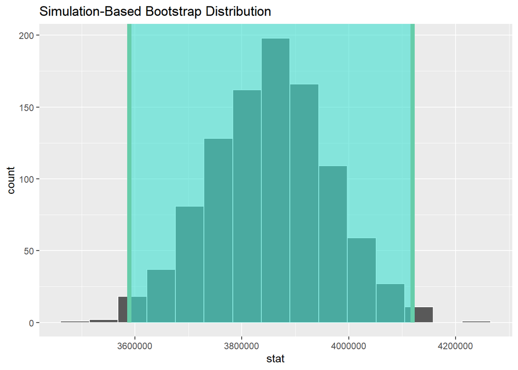

## Escolha do método

Adotou-se o método T-Student (t-test) para testar a hipótese formulada. A potencialidade desse método, para o caso proposto, reside em sua capacidade de identificar se as médias de dois grupos são realmente diferentes do ponto de vista estatístico. No caso, a comparação é entre a média das dotações das “emendas PIX” e a média das dotações das “emendas não PIX”. A limitação desse método é sua incapacidade de lidar com mais de duas amostras, mas para o presente caso isso não foi um problema.

## Teste de Hipótese

Como passo seguinte, testa-se a hipótese de que a dispensa de finalidade definida (“efeito PIX”) aumenta o valor médio das emendas individuais. Supõe-se que a desnecessidade de especificar o gasto possibilita o “empacotamento” de diferentes ações.

Em resumo:

H0: não há diferença nas médias de emenda PIX e não PIX.

H1: média de emenda PIX > média emenda não PIX

Teste com intervalo de confiança de 99%:

## Resultados (output do script)

```r
t.test(EmendasPIX$Dotação, EmendasNÃOPix$Dotação, alternative = "greater", conf=0.99)
```

```
##
##  Welch Two Sample t-test
##
## data:  EmendasPIX$Dotação and EmendasNÃOPix$Dotação
## t = 20.915, df = 961.48, p-value < 2.2e-16
## alternative hypothesis: true difference in means is greater than 0
## 99 percent confidence interval:
##  2142090     Inf
## sample estimates:
## mean of x mean of y
##   3853708   1443032
```

## Resultados (interpretação)

Dado o resultado extremamente baixo do p-valor (2.2e-16), pode-se rejeitar H0, havendo evidência estatística em favor da hipótese alternativa formulada (H1) com intervalo de confiança de 99%. Isso equivale a dizer que seria altamente improvável encontrar amostras que corroborassem a hipótese nula. A média das Emendas não PIX, que é de R$ 1,4 milhão, situa-se na zona de rejeição de H0.